# Strikeout Home/Away Effects

Jim Albert

7/19/2017

#### The Problem and Multilevel Model

Interested in learning about the strikeout rates of baseball players and how strikeout rates vary between home and away games. We know there is a positive home field effect, but we wonder if the size of the effect varies across players.

Suppose that $y_{ij}$ denotes the number of strikeouts in $n_{ij}$ at-bats of the $i$th player in the $j$th situation ($j = 1, 2$ for home and away).

The multilevel model:
$$y_{ij} \sim Binom(n_{ij}, p_{ij})$$

$$logit \, \, p_{ij} = \mu + \eta_i + \delta_i \times (HOME = j)$$
$$\eta_i \sim N(0, \sigma_1), \, \, \delta_j \sim N(0, \sigma_2)$$

where $(\mu, \sigma_1, \sigma_2)$ are given “vague priors”

The random effect $\eta_i$ represents the strikeout “ability” of the $i$th player and $\delta_i$ represents the ability of the $i$ player to do better during home games.

#### The Data and Initial Exploration

Get strikeout data for all players in 2016 season for home and away games from Retrosheet play-by-play files.

```r
load("~/Google Drive/Retrosheet/pbp.2016.Rdata")
```

Need some packages:

```r
library(dplyr)
library(ggplot2)
library(rstanarm)
library(bayesplot)
```

```r
d2016 %>% filter(AB_FL == TRUE) %>%
  select(BAT_ID, BAT_HOME_ID, EVENT_CD) %>%
  mutate(K = EVENT_CD == 3) -> d
```

Limit to players with at least 300 at-bats:

```r
S0 <- summarize(group_by(d, BAT_ID), AB=n())
inner_join(d, S0) %>% filter(AB >= 300) -> d
```

Collect home and away K data:

```r
S <- summarize(group_by(d, BAT_ID, BAT_HOME_ID),
               N = n(),
               y = sum(K),
               z = N - y)
```

Do an exploratory plot. Here I compute the logits of the estimated probabilities of strikeout for home and away games. Graph the mean logit against the (HOME - AWAY) difference. On average, one would expect batters to do better at home games, so the mean logit difference is negative.

```r
S1 <- inner_join(filter(S, BAT_HOME_ID==0),
                 filter(S, BAT_HOME_ID==1),
                 by="BAT_ID")
S1 <- mutate(S1,
             logit.x=log(y.x / z.x),
             logit.y=log(y.y / z.y))
S1
```

```
## # A tibble: 245 x 11
## # Groups:   BAT_ID [245]
##      BAT_ID BAT_HOME_ID.x   N.x   y.x   z.x BAT_HOME_ID.y   N.y   y.y
##      <fctr>         <int> <int> <int> <int>         <int> <int> <int>
##  1 abrej003             0   329    69   260             1   295    56
##  2 alony001             0   266    41   225             1   216    33
##  3 altuj001             0   319    32   287             1   321    38
##  4 alvap001             0   143    47    96             1   194    50
##  5 andet001             0   194    62   132             1   216    55
##  6 andre001             0   261    42   219             1   245    28
##  7 aokin001             0   232    25   207             1   185    20
##  8 arenn001             0   307    55   252             1   311    48
##  9 aybae001             0   205    41   164             1   210    29
## 10 baezj001             0   218    57   161             1   203    51
## # ... with 235 more rows, and 3 more variables: z.y <int>, logit.x <dbl>,
## #   logit.y <dbl>
```

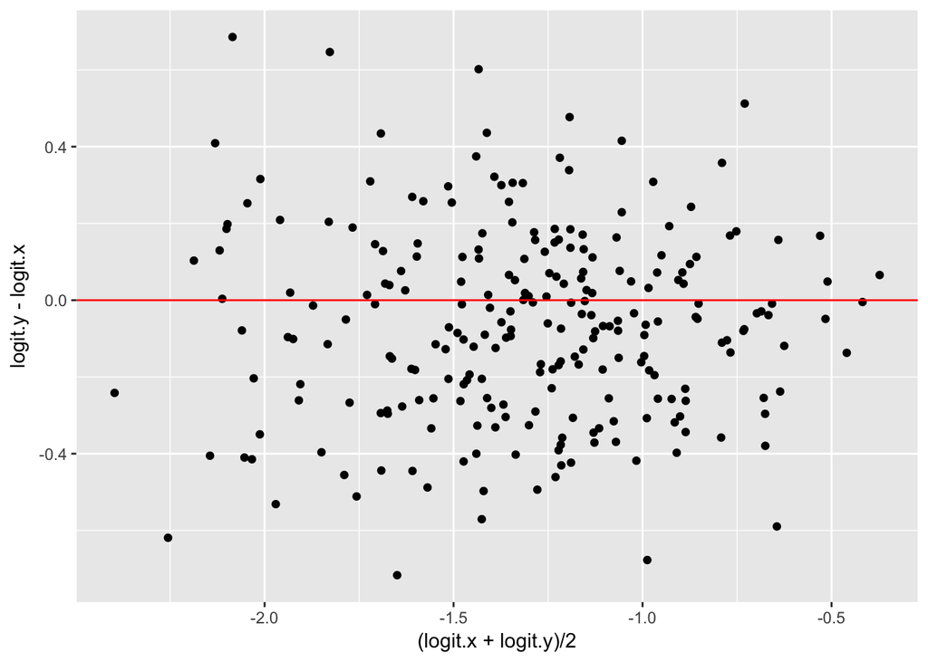

```r
ggplot(S1, aes((logit.x + logit.y) / 2,
               logit.y - logit.x)) +
  geom_point() +
  geom_hline(yintercept = 0, color="red")
```

#### Fit Multilevel Model on Stan

```
bfit <- stan_glmer(cbind(y, z) ~
                   (1 + BAT_HOME_ID | BAT_ID),
                   data=S,
                   family=binomial)
```

We load the output `bfit` from previous MCMC run. By use of the `as.array` function, we convert the output into a simulated array where the dimensions correspond to simulation, chain, parameter.

```r
load("homefit.Rdata")
posterior <- as.array(bfit)
```

The `prior_summary` function gives information about the default priors chosen.

```r
prior_summary(bfit)
```

```
## Priors for model 'bfit'
## ------
## Intercept (after predictors centered)
##  ~ normal(location = 0, scale = 10)
##
## Covariance
##  ~ decov(reg. = 1, conc. = 1, shape = 1, scale = 1)
## ------
## See help('prior_summary.stanreg') for more details
```

#### Graphs of the Posterior

First define a particular theme element for drawing the title.

```r
TH <- theme(
  plot.title = element_text(
    colour = "blue",
    size = 18,
    hjust = 0.5,
    vjust = 0.8,
    angle = 0
  )
)
```

Some work to get indices of parameters of interest:

```r
posterior[, , c(492, 494)] <-
  sqrt(posterior[, , c(492, 494)])
intercept_indices <- seq(2, 490, by=2)
slope_indices <- seq(3, 491, by=2)
attr(posterior, "dimnames")[[3]][intercept_indices] <-
        paste('a', 1:245, sep="")
attr(posterior, "dimnames")[[3]][slope_indices] <-
  paste('b', 1:245, sep="")
attr(posterior, "dimnames")[[3]][c(492, 494)] <-
  c("SD_a", "SD_b")
var_names <- attr(posterior, "dimnames")[[3]]
```

We show the posterior densities for a few of the intercept parameters (the person effects).

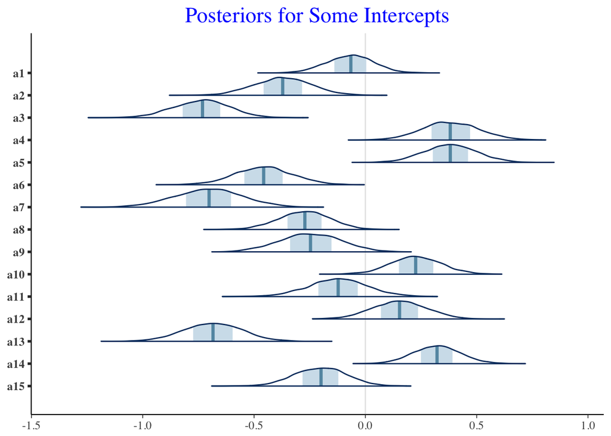

```r
mcmc_areas(posterior, pars=var_names[seq(2, 30, by=2)]) +
  ggtitle("Posteriors for Some Intercepts") + TH
```

Here are graphs of the posterior densities for a few of the slope parameters (the home/away effects).

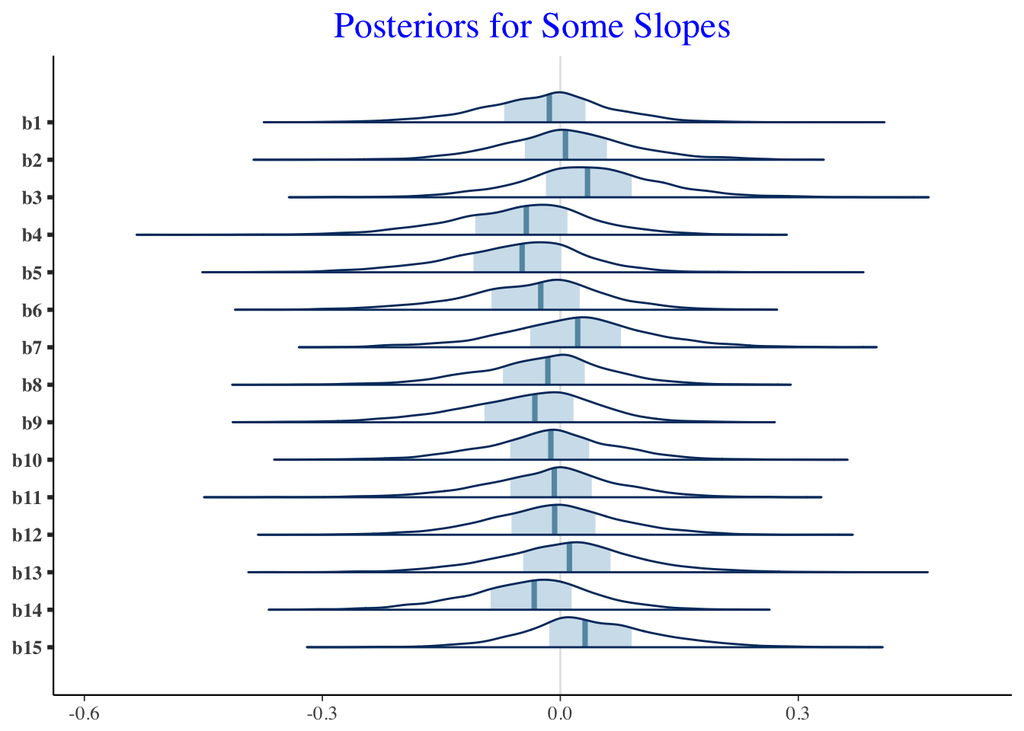

```r
mcmc_areas(posterior, pars=var_names[seq(3, 31, by=2)]) +
  ggtitle("Posteriors for Some Slopes") + TH
```

Here are posterior probability intervals for all intercepts:

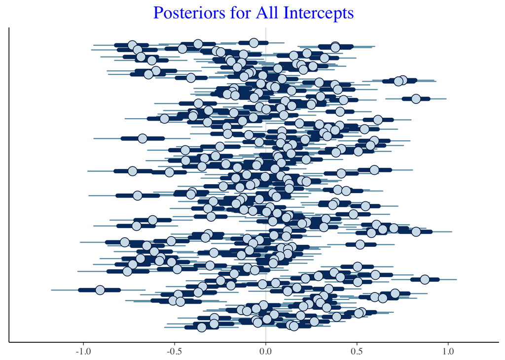

```r
mcmc_intervals(posterior,
               pars=var_names[intercept_indices]) +
  theme(axis.title.y=element_blank(),
        axis.text.y=element_blank(),
        axis.ticks.y=element_blank()) +
  ggtitle("Posteriors for All Intercepts") + TH
```

Here are posterior probability intervals for all slopes:

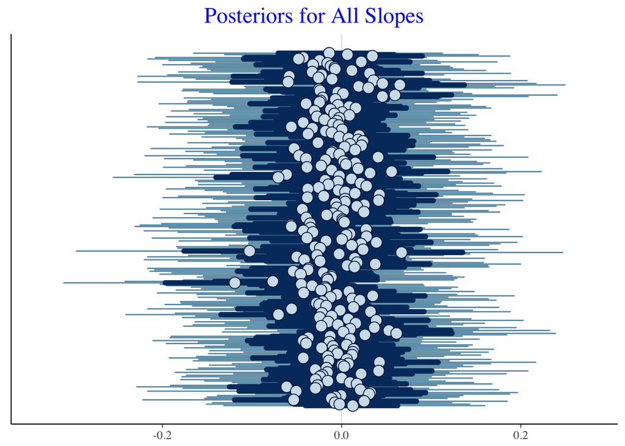

```r
mcmc_intervals(posterior,
               pars=var_names[slope_indices]) +
  theme(axis.title.y=element_blank(),
        axis.text.y=element_blank(),
        axis.ticks.y=element_blank()) +
  ggtitle("Posteriors for All Slopes") + TH
```

Here are posterior densities for the two random effects standard deviations $\sigma_1$ and $\sigma_2$. As one would expect, the variability of the strikeout talents is much larger than the variability of the home/away talents.

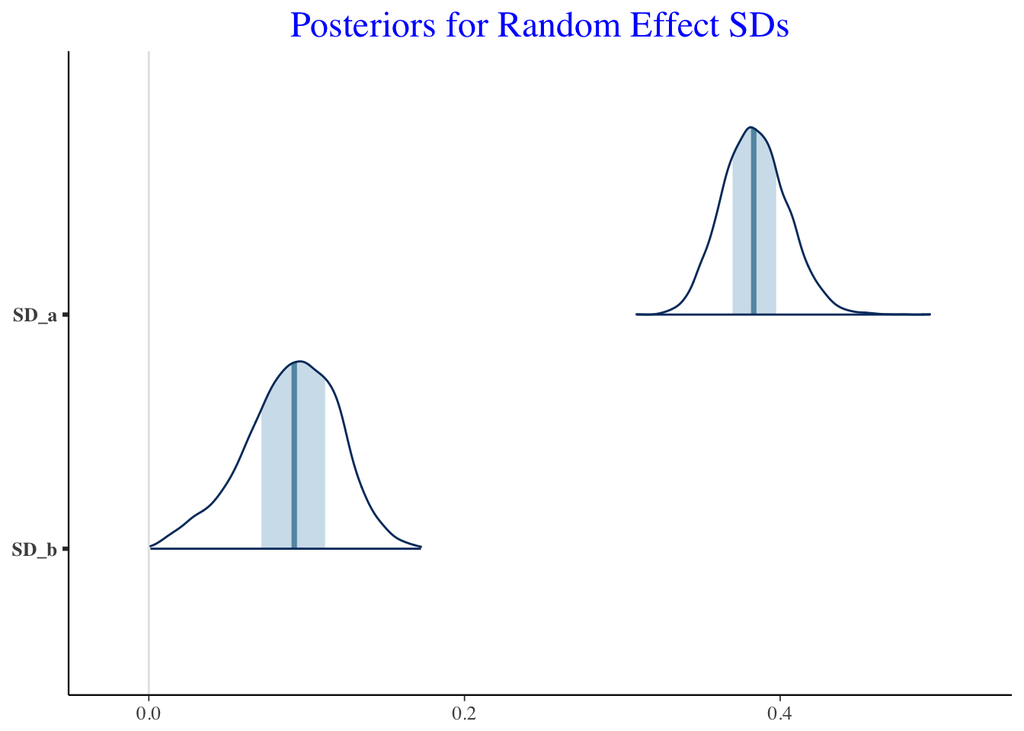

```r
mcmc_areas(posterior, pars=var_names[c(492, 494)]) +
  ggtitle("Posteriors for Random Effect SDs") + TH
```